# Statistik och dataanalys I

F6: Samband mellan numeriska variabler och korrelation

Valentin Zulj

## Vad har vi gjort hittills?

- Som statistiker är vi ofta intresserade av att studera samband mellan variabler
- Hittills har vi tittat på
  - Samband mellan två eller flera kategoriska variabler, med hjälp av korstabeller och stapeldiagram
  - Samband mellan en numerisk och en kategorisk variabel, med hjälp av låddiagram och histogram
- Ett naturligt steg framåt är att nu börja titta på **samband mellan två numeriska variabler**

## Vad vi ska göra nu?

- Vi ska som sagt prata om att undersöka samband mellan numeriska variabler
- Denna typ av sambandsstudier är väldigt vanliga, och förekommer ofta i både studentuppsatser och i publicerade forskningsartiklar
- Mer specifikt så kommer vi att titta på
  - Spridningsdiagram
  - Linjära samband och korrelation
  - Korrelation och kausalitet
- Detta leder oss fram till ämnet för nästa föreläsning, nämligen **linjär regression**

# Spridningsdiagram

## Tidsserier

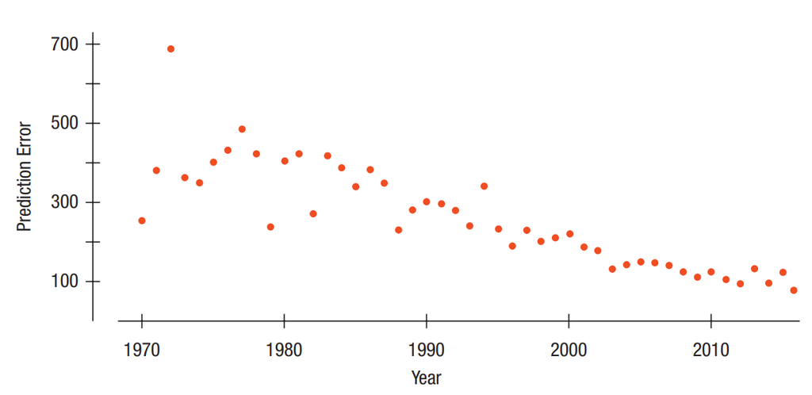

- Vi har redan tittat på diagram över tidsserier, där vi studerar hur en numerisk variabel utvecklas över en given tidsperiod
- Detta är exempel exempel på samband mellan två numeriska variabler, då även tiden är en numerisk variabel
- Figuren visar en tidsserie av årsvisa genomsnittliga prediktionsfel i nautiska mil i lokalisering av orkaner i Atlanten

## Spridningsdiagram (scatter plots)

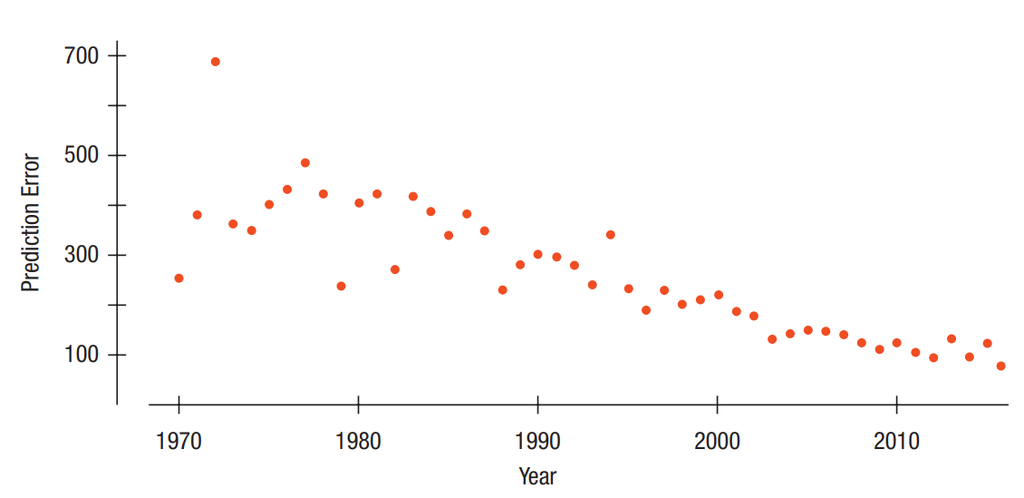

- Samband mellan två numeriska variabler kan illustreras med hjälp av ett **spridningsdiagram** (*scatter plot*)
- Diagrammet ovan illustrerar en tidsserie, och är alltså ett exempel på ett spridningsdiagram

## Spridningsdiagram - X och Y

- Hur bestämmer vi vilken variabel som är y och vilken som är x?
- Ofta finns det inget korrekt svar, men vi kan använda tumregler för vad som är rimligast
- Enklast att tänka i termer av prediktion
  - Variabeln av intresse att prediktera väljs som y
  - Variabeln som hjälper oss att prediktera väljs som x
- Är det rimligt att fråga sig om variabeln på y-axeln påverkas av variabeln på x-axeln? Blir frågan mer rimlig om variablerna byter plats?

## Spridningsdiagram - X och Y

- Bilden visar räckvidden per gallon bensin mot vikten hos en bil
- Vilken av följande frågor låter rimligast?
  - Brukar bensinförbrukningen vara högre för bilar som väger mer?
  - Brukar bilar vara tyngre om de förbrukar mer bensin?
- Om den första frågan låter mer rimlig väljer vi grafen till vänster

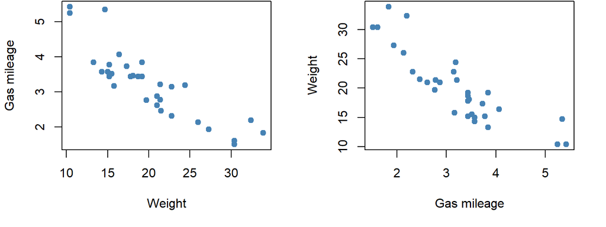

## Spridningsdiagram - X och Y

- Det finns flera olika namn som används för x- respektive y-variabeln
- Variabeln y kallas i vissa sammanhang **responsvariabeln** (*response variable*)
- Variabeln x kallas ibland för **förklaringsvariabeln** (*explanatory variable*)
- Ett annat vanligt namn för y är **beroende variabel** (*dependent variable*), och x blir då en **oberoende variabel** (*independent variable*)
- Andra vanligt förekommande namn för x-variabeln är **prediktor** (*predictor*), **kovariat** (*covariate*), och **förklarande variabel** (*explanatory variable*)
- Inom maskininlärning kallas förklarande variabler ofta för **features**

# Linjära samband och korrelation

## Linjära samband mellan numeriska variabler

- Vi har pratat vagt om styrkan i ett samband, men kan vi på något sätt mäta hur *starkt* ett *linjärt* samband mellan två numeriska variabler är?
- Vi lägger till att vi gärna vill ha ett mått som är oberoende av enheter
- **Exempel:** Figur 6.2 och 6.3 i De Veaux et al. (2021) visar ett antal personers vikt och längd, och vi ser liknande samband oavsett om vikt ges i kg eller lbs
- Den enda skillnaden är olika skalor på y-axeln i de två graferna, och vi vill ha ett mått som inte påverkas av dessa skillnader i skala

## Linjära samband mellan numeriska variabler

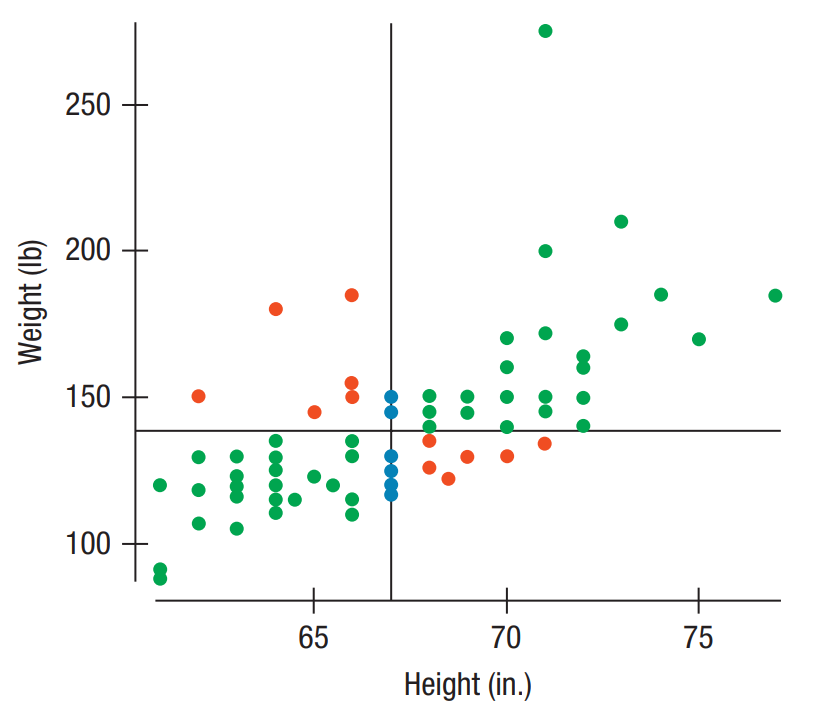

- Linjerna som representerar variablernas medelvärden delar in grafen i fyra delar, och färgen på punkterna skiljer sig åt mellan delarna
- Punkterna är **gröna** om *både x och y är större* än medelvärdet eller om *både x och y är mindre* än medelvärdet
- Punkterna är **röda** om de är mindre än medelvärdet på den ena skalan och större än medelvärdet på den andra skalan

## Linjära samband mellan numeriska variabler

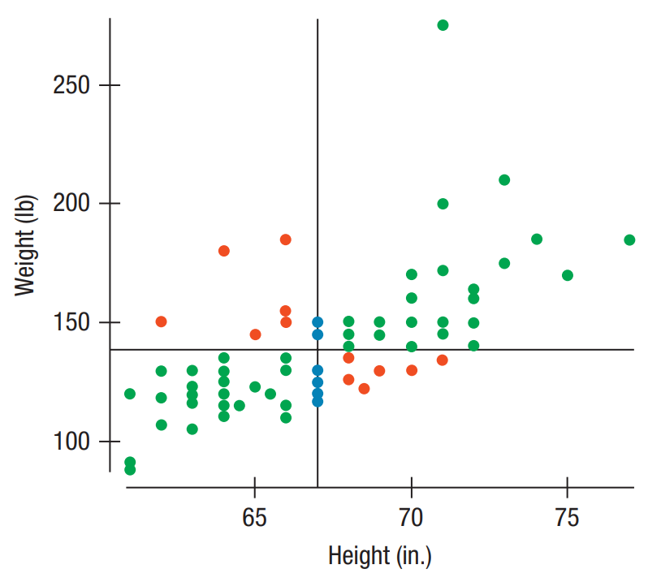

- De **gröna** punkterna påverkar sambandet i *positiv* riktning
- De **röda** punkterna påverkar sambandet i *negativ* riktning
- De gröna punkterna är fler, vilket indikerar att sambandet är positivt
- Fler röda punkter hade indikerat ett *negativt* samband

## Linjära samband mellan numeriska variabler

- Att räkna punkter i olika sektioner av plotten är ett enkelt och intuitivt sätt att bedöma riktningen på sambandet
- **Men:** Det är inte ovanligt att ha tusentals datapunkter (jobbigt att räkna)
- **Och:** Vi vill ofta kunna säga något om *hur starkt* det linjära sambandet är
- Vi vill så ha ett mer konkret mått, som inte beror på vilka enheter vi använder för variabler

## Standardiserade numeriska variabler

- Vi har tidgare räknat med **z-värden** för numeriska variabler – dessa har fördelen att de är lika stora oavsett enhet som en variabel mäts i
- Vi kallar z för en *standardiserad* variabel, då den har en “standardenhet”

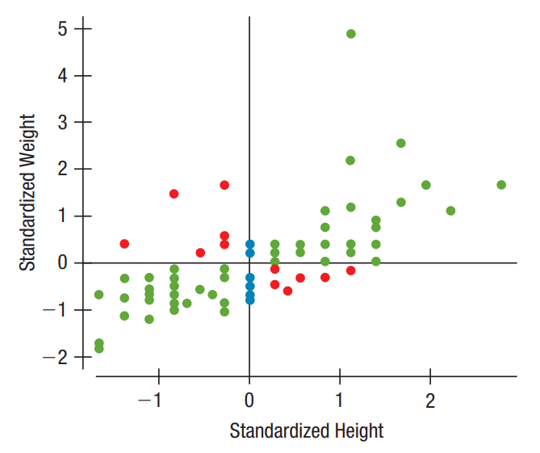

## Standardiserade numeriska variabler

- Vi förtydligar detta med ett exempel i R, med variablerna `weight_pounds` och `weight_kg` (vikt på olika bilmodeller)
- Variablerna anger vikt på samma bilar, fast i olika enheter, och vi ska visa att de får samma värden efter standardisering

```r
head(weight_pounds)
```

```
[1] 2.620 2.875 2.320 3.215 3.440 3.460
```

```r
weight_kg <- weight_pounds * 0.454
head(weight_kg)
```

```
[1] 1.18948 1.30525 1.05328 1.45961 1.56176 1.57084
```

## Standardiserade numeriska variabler

- Nu standardiserar vi var och en av variablerna till z-värden enligt
  $$z_i = \cfrac{x_i - \bar{x}}{s},\;\;\;\; \bar{x} = \cfrac{\sum_i x_i}{n}, \;\;\;\; s=\sqrt{\cfrac{\sum_i (x_i-\bar{x})^2}{n-1}}.$$
- Genom standardisering byter vi enhet från *kg* eller *pounds* till *standardavvikelser*
- Eftersom variablerna mäter samma sak förväntar vi oss att de ska få samma standardiserade värden

## Standardiserade numeriska variabler

- Vi standardiserar i R för att dubbelkolla, och börjar med `weight_pounds`

```r
weight_pounds_z <- (weight_pounds - mean(weight_pounds)) /
  sd(weight_pounds)
head(weight_pounds_z) |> round(3)
```

```
[1] -0.610 -0.350 -0.917 -0.002  0.228  0.248
```

- Och fortsätter med `weight_kg`

```r
weight_kg_z <- (weight_kg - mean(weight_kg)) /
  sd(weight_kg)
head(weight_kg_z) |> round(3)
```

```
[1] -0.610 -0.350 -0.917 -0.002  0.228  0.248
```

- De standardiserade variablerna får samma värden oavsett vilken viktenhet vi använder från början!

## Korrelationskoefficienten

- För att mäta styrkan på det linjära sambandet använder vi **korrelationskoefficienten** (*correlation coefficient*), som beräknas enligt

$$r = \cfrac{\sum{z_x z_y}}{n-1}$$

## Korrelationskoefficienten

- Om korrelationskoefficienten är positiv har vi ett positivt linjärt samband mellan variablerna
- Omkorrelationskoefficienten är negativ har vi ett negativt linjärt samband
- Korrelationsmåttet är *symmetriskt*, vilket betyder att korrelationen mellan $x$ och $y$ är densamma som korrelationen mellan $y$ och $x$

## Korrelationskoefficienten

- Vi kommer ihåg att korrelationskoefficienten beräknas som
  $$r = \cfrac{\sum{z_x z_y}}{n-1}$$
- Vi ser i formeln att korrelationskoefficienten blir positiv om uttrycket $\sum{z_x z_y}$ är positivt, och att korrelationen är starkare när uttrycket är stort
- När uttrycket $\sum{z_x z_y}$ är negativt blir korrelationen negativ, och om uttrycket är ett stort negativt tal är den negativa korrelationen starkare

## Korrelationskoefficienten

- Notera att multiplikationen $z_x z_y$ är positiv när
  - både $z_x$ och $z_y$ är positiva
  - både $z_x$ och $z_y$ är negativa
- På motsvarande sätt är multiplikationen $z_x z_y$ är negativ när
  - $z_x$ är positiv och $z_y$ är negativ, eller vice versa

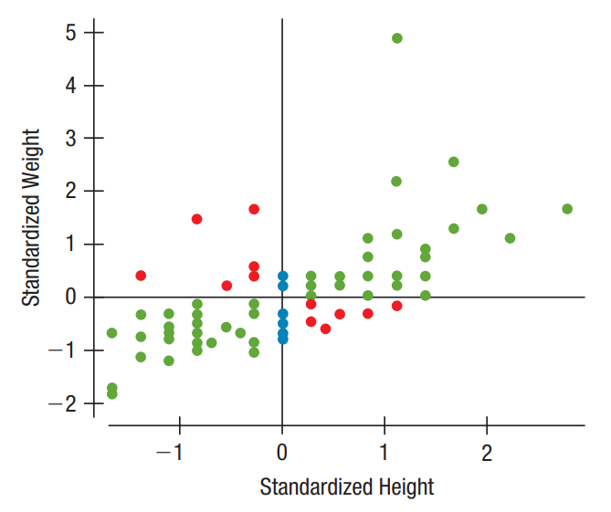

## Korrelationskoefficienten

- Den här grafen visar två exempel på hur ett **perfekt positivt** linjärt samband kan se ut
- Både $y_1$ och $y_2$ är perfekt korrelerade med $x$, dvs $r = 1$ för båda sambanden, trots att linjerna har olika lutning

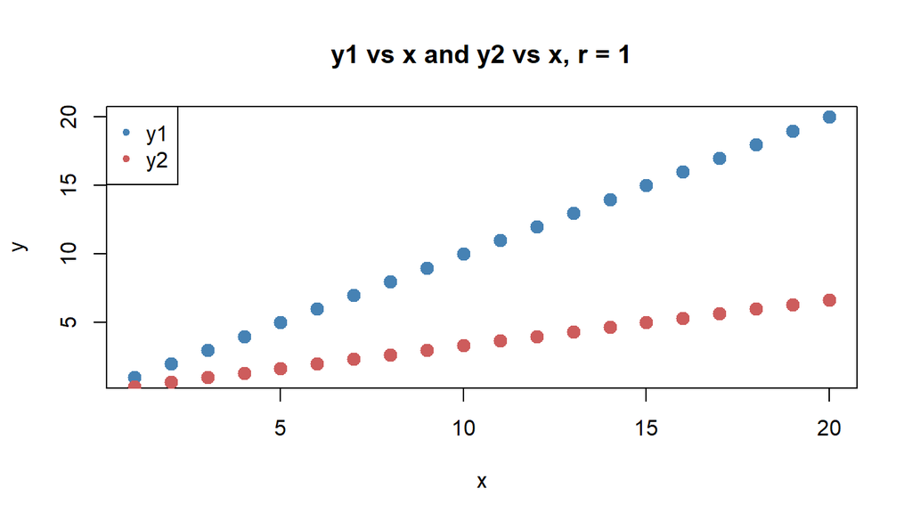

## Korrelationskoefficienten

- Den här grafen visar två exempel på hur ett **perfekt negativt** linjärt samband kan se ut
- Både $y_1$ och $y_2$ är perfekt korrelerade med $x$, dvs $r = -1$ för båda sambanden, trots att linjerna har olika lutning

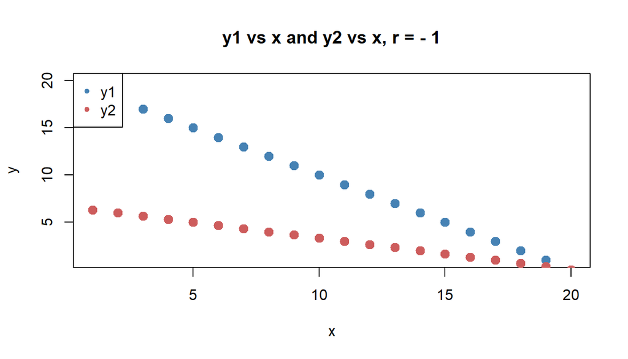

## Korrelationskoefficienten

- De här graferna visar två exempel på linjära samband som inte är perfekta
- Den blå grafen visar ett en **starkare korrelation** än den röda grafen, trots att de blå punkterna är utspridda medan de röda punkter följer en tydlig linje
- Även om de blå punkterna är mer spridda följer de en **rak** linje, medan de röda punkterna följer en böjd linje (kurva)
- Kom ihåg att korrelation **bara** mäter styrkan i det **linjära** sambandet

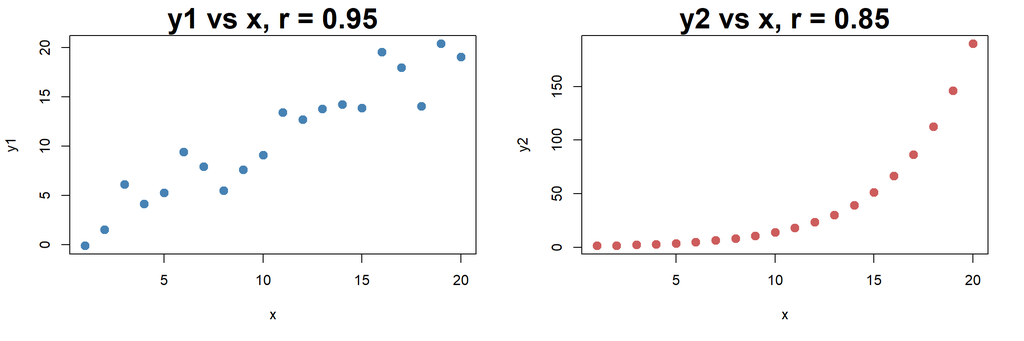

## Korrelationskoefficienten

- Bara för att det finns *något* samband betyder det **inte** att det finns korrelation, utan korrelation mäter **linjärt** samband
- I figuren nedan finns ett uppenbart samband mellan god smak (y) och baktemperatur (x) för kladdkakor – ändå är korrelationen nära noll!

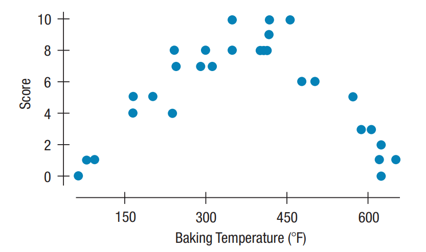

## Korrelationer i R

- I R kan vi enkelt rita ett spridningsdiagram för 2 numeriska variabler
- Datamaterialet *trees* anger omkrets (girth), höjd (height) och volym (volume) för 31 träd

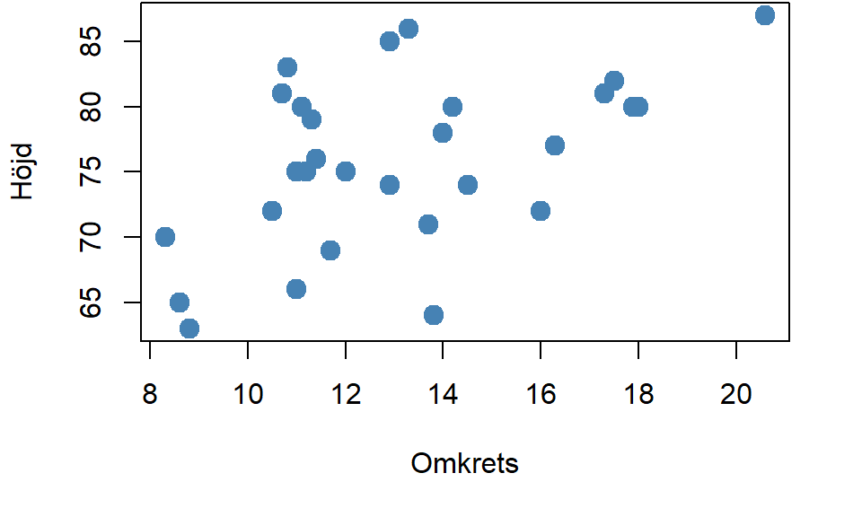

```r
data(trees)
plot(x=trees$Girth, y=trees$Height, pch=19, cex=1.5,
     col="steelblue", xlab="Omkrets", ylab="Höjd")
```

## Korrelationer i R

- Vi kan räkna ut korrelationskoefficienten för två variabler med funktionen `cor()`

```r
cor(trees$Girth, trees$Height) # Korrelation omkrets, höjd
```

```
[1] 0.5192801
```

# Korrleation och kausalitet

## Korrelation är inte kausalitet

- Figur 6.10 i De Veaux et al. (2021) visar ett tydligt linjärt samband mellan antalet storkar och befolkningsmängden under sju år i en stad i Tyskland
- Det sägs ibland att storkar kommer med barn, och det skulle ju kunna förklara varför antalet människor blir fler när det kommer många storkar
- Korrelationskoefficienten är $r=0.97$, så det linjära sambandet är starkt

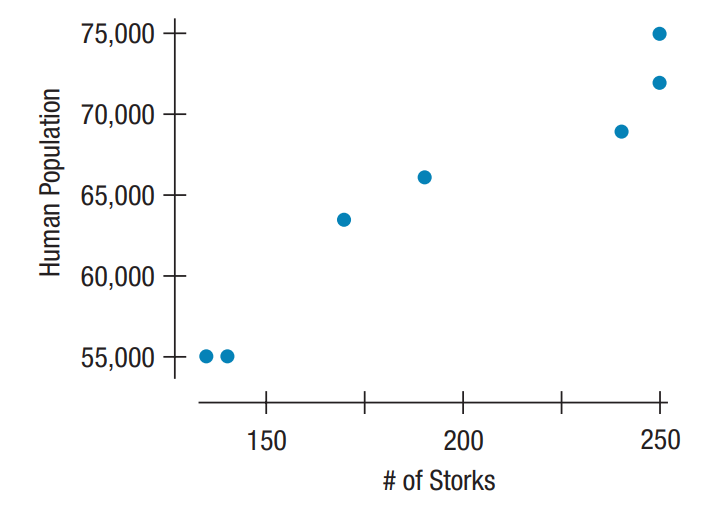

## Korrelation är inte kausalitet

- Slutsatsen om att fler storkar leder till fler människor är en **kausal** tolkning av korrelationen – den gör en utsaga om ett **orsakssamband**
- Är slutsatsen rimlig? Skulle vi kunna få barn även om storkarna försvann?
- Kanske är sambandet det omvända? Storkar bygger bon på skorstenar, och fler människor betyder fler hus med skorstenar där storkarna kan bygga bon
- Allmänt bör vi vara försiktiga med att dra snabba slutsatser av det här slaget
- Det kan t.ex. finnas en **dold variabel** som förklarar både $x$ och $y$, och som gör det svårt för oss att identifiera kausaliteten helt
- Detta betyder dock inte att kausalitet alltid saknas – ibland finns det kausalitet och ibland finns det inte
- Huvudsaken är att det krävs mer utförliga och specifikt designade studier för att etablera kausala relationer

## Korrelation är inte kausalitet

- **Kausal tolkning:** När det produceras mer glass måste folk äta upp glassen, och för mycket glass gör att människor får håll och drunknar i badet
- **Omvänd kausal tolkning:** Folk blir ledsna och tröstäter glass när de läser om drunkningsolyckor, så mer glass produceras i tider då många drunknar

## Korrelation är inte kausalitet

- Ingen av de kausala tolkningarna är särskilt bra, men vi har en uppenbar *lurking variable*
- **Årstiden** påverkar både antalet drunkningsolyckor och glassproduktionen! Folk badar mer och äter mer glass under sommarmånader
- Sambandet uppstår alltså på grund av att båda variablerna råkar korrelera positivt med temperatur

# Samband mellan fler än två numeriska variabler

## Samband mellan fler än två numeriska variabler

- Om vi har tre eller fler numeriska variabler kan vi göra parvisa spridningsdiagram med funktionen `pairs()` i R

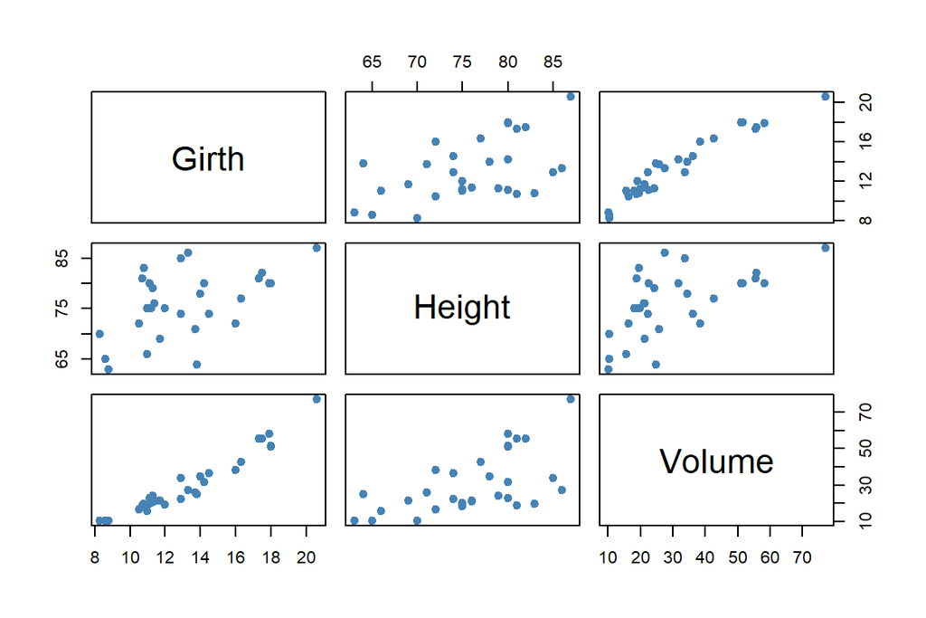

```r
# trees är en data frame
pairs(trees, col="steelblue", pch=19, cex=1)
```

## Samband mellan fler än två numeriska variabler

- Om vi har flera variabler kan vi skapa en tabell med parvisa korrelationer
- Tabell 6.1 i De Veaux et al. (2021) innehåller t.ex. en korrelationstabell för olika finansiella mått från Forbes

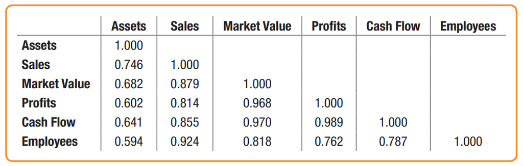

- Varför är är alla värden längs diagonalen 1?
- Vad kan vi säga om den tomma delen av tabellen ovanför diagonalen?

## Samband mellan fler än två numeriska variabler

- I R funktionen `cor()` även skapa en korrelationstabeller, men då måste vi ge en hel data frame som input
- **Viktigt!** Detta fungerar bara om alla variabler i vår data frame är **numeriska**

```r
cor(trees)
```

```
           Girth    Height    Volume
Girth  1.0000000 0.5192801 0.9671194
Height 0.5192801 1.0000000 0.5982497
Volume 0.9671194 0.5982497 1.0000000
```

- Jämför matrisens nedre vänstra del med dess övre högra del!

## Betingad korrelation - Ett vilseledande samband

- Vi ska nu titta på ett exempel där en dold variabel (lurking variable) helt förändrar vår tolkning av sambandet
- **Scenario:** Vi undersöker sambandet mellan lön och yrkeserfarenhet hos ett företag
- När vi plottar alla data tillsammans ser vi en typ av samband
- När vi betingar på en nyintroducerad variabel, yrkeskategori, så blir bilden en annan
- Notera att detta endast är data som jag har simulerat i R

## Betingad korrelation, forts.

- Vi kan inte se något (eller möjligtvis ett väldigt svagt) samband mellan erfarenhet och lön

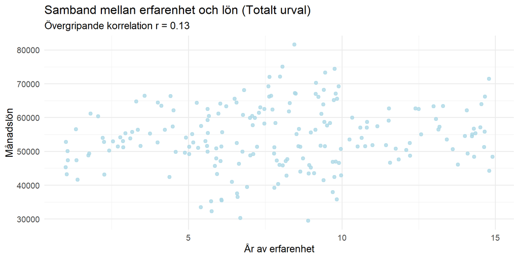

## Betingad korrelation, forts.

- Nu kan vi tydligt se ett samband mellan erfarenhet och lön, när vi har betingat på yrkeskategori
- Detta är ett annat exempel på Simpson’s paradox (se föreläsning 3)

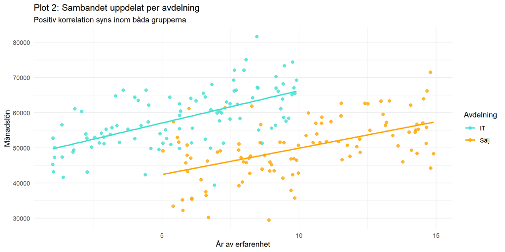

## Credits

Dessa slides skapades av Karl Sigfrid för kursen Statistik och Dataanalys I och har uppdaterats av Oskar Gustafsson och Valentin Zulj